# Sowing Dates for Crop suitability models

# Introduction

The Innovation Recommendation Domain Mapping model splits the growing period into separate growth stages, and applies different thresholds for the climatic criteria for each or some of the growth stages.

In order to position the growing period and specific growth stages within the calendar year we need to know when the crop is normally sown planted or transplanted.

For small areas a single date will satisfy this requirement, whereas for a large country like Nigeria there will be different sowing dates as the rainy season progresses from South to North.

There are a number of ways of identifying and mapping the sowing date. The most reliable is to ask producers themselves, but this also has its disadvantages because of poor recall, or changing dates, or how to deal with outliers. Another method is to ask extension agents the average date in a particular geography, this has the advantage of using a mixture of local knowledge with some professional skill at estimation. Alternatives include models based on daily rainfall and temperature data, or direct observation of crop growth via satellite imagery.

None of these methods is foolproof, due to the fact that the seasons are dynamic from year to year and we are trying to model for a ‘normal’ season.

# Sowing date data

There are a number of spatial data products of sowing dates.

The (rainfed) crops that we are going to model are:

- cassava
- cowpea
- maize
- rice
- sweet potato

These are highlighted in the table below.

Name

Source

Resolution

Priority Crops

Creation Date

Citation

Crop Calendar Dataset (CCD)

Center for Sustainability and the Global Environment

5 minute and 0.5 degree

- **Cassava**
- **Maize**
- Millet
- Potatoes
- **Pulses**
- **Rice**
- **Sweet Potato**
- Wheat

2010

(Sacks, 2010)

SAtellite-derived CRop calendar for Agricultural simulations (SACRA) Provides sowing date for the ‘dominant’ crop in each grid cell

RIKEN Advanced Institute for Computational Science

5 arcmin

- Wheat
- **Maize**
- **Rice**
- Millet
- Potatoes
- **Cassava**
- **Pulses**
- Others perennial
- Others annual

2015

Kotsuki and Tanaka (2015, HESS)

Livelihood Zone Seasonal and Consumption Calendars

FEWSNET

Selected Livelihood Zones

2018

FEWSNET (2018)

(NG01 – Sokoto millet, cowpeas, groundnuts and livestock)

- Millet
- Rice (irrigated)
- Sorghum
- **Sweet potatoes**
- **Cowpeas**

(NG02 – Kano-Katsina Sahel: millet, sorghum, sesame and gum arabic)

- Millet
- **Cowpeas**
- **Sweet potatoes**

(NG03 – Kano-Katsina Sudan: maize, sorghum, groundnuts and rice)

- **Rice**
- **Maize**
- **Cowpeas**

(NG04 – Northeast Sahel: millet, sesame, cowpeas and livestock)

- Millet
- **Cowpea** (early)

(NG05 – Borno-Yobe-Bauchi millet, cowpeas, groundnuts and sesame)

- Millet
- **Cowpeas**
- **Rice** (rainfed)
- Rice (irrigated)

(NG06 – Sokot-Rima-Kano riverine rice and fishing and NG07 – Komadugu-Yobe irrigated peppers with rice, millet and vegetables)

- **Rice** (rainfed)
- Rice (irrigated)
- Millet
- **Maize** (rainfed)
- Maize (irrigated)
- **Cowpeas**
- **Cassava**
- **Sweet potatoes**

(NG08 – Lake Chad fishing, maize, cowpeas and vegetables and NG09 – Chad Basin: dry season masakwa sorghum and wheat)

- Wheat (irrigated)
- Maize (irrigated)
- Rice (irrigated)
- **Cowpeas**
- Millet

(NG10 – Hadeija-Nguru wetlands: mixed cereals and vegetables)

- Rice (irrig. - Hadeija Valley Project)
- Rice (irrigated)
- **Cassava**
- **Cowpeas**
- Wheat
- **Maize**
- Millet

(NG11 – Northwest sorghum, maize, soybeans and rice and NG12 – Northwest sorghum, maize and cotton with cross-border trade)

- **Rice** (rainfed)
- Rice (irrigated)
- **Maize**
- **Cowpeas**

(NG13 – Northwest and central maize, rice, cowpeas and sweet potatoes and NG14 – Central sorghum dominant with maize, groundnuts and cowpeas)

- **Maize** (rainfed)
- Maize (irrigated - cobs for roasting)
- **Cowpea**
- **Sweet potatoes**
- Millet

(NG15 – Northeast maize dominant with rice, soybeans and groundnuts)

- **Maize**
- **Rice** (rainfed)
- **Cowpeas**

(NG16 – High plateau Irish potatoes, maize, acha (Digitaria) and livestock and NG17 – Lower plateau rice, sorghum and cattle)

- Irish potato (wet and dry)
- **Maize** (rainfed)
- Maize irrigated)
- **Rice** (rainfed)
- Rice (irrigated)
- **Cassava**

(NG18 – Ginger and turmeric with maize, sorghum, yams and acha (Digitaria) and NG20 – Central yams and maize belt, with cassava, rice and soybeans)

- **Maize** (rainfed)
- Maize (irrigated)
- **Cassava**

(NG19 – Benue river sugar cane, rice and sugar estate labor, NG21 – Niger and Benue rivers floodplain rice with maize, vegetables and livestock, and NG35 – Niger and Benue rivers fishing and food crops)

- Rice (irrigated)
- **Rice** (rainfed)
- **Maize**
- **Cassava**

(NG23 – Citrus fruits with yams, cassava and groundnuts, NG24 – Cocoa dominant with oil palms, cereals and tubers, and NG30 – Cashews with tubers, maize and oil palms)

- **Cassava**
- **Maize** (early)
- **Maize** (late)
- **Rice** (rainfed)
- Rice (irrigated)
- **Sweet potatoes**
- **Cowpea**

(NG22 – Cassava dominant with rice, maize, yams and tree-crops, NG26 – Cross River cocoa with oil palms, rice, yams and plantain, NG27 – Southeast rice dominant with cassava, yams and oil palms, and NG28 – Southwest cocoa with oil palms, tubers and cereals)

- **Rice** (rainfed)
- **Cassava**
- **Maize**
- **Sweet Potato**

(NG22 – Cassava dominant with rice, maize, yams and tree-crops and NG33 – Southeast cassava and oil palms with extensive off-farm work and trade)

- **Cassava**
- **Maize**
- **Rice** (rainfed)
- Rice (irrigated)
- Plaintain
- Cocoyam

(NG25 – Mambila highland: cattle, maize, Irish potatoes, tea, coffee and kola nuts)

- **Maize**
- Irish potatoes
- Beans
- **Sweet potatoes**

(NG29 – Southwest rice, cassava and cattle with cross-border trade)

- **Rice**
- **Cassava**
- **Maize**

(NG31 – Lagos peri-urban – fishing, poultry, piggeries, market gardening and coconuts and NG32 – Coastal belt: maritime and inland fishing, cassava, plantain, oil palms and rubber)

- **Rice**
- **Cassava**
- **Maize**

(NG34 – Northeast cattle, small ruminants and food crops with cross-border livestock trade)

- Millet
- **Rice** (rainfed)
- **Maize**
- **Cowpea**

# Load the Nigeria boundary

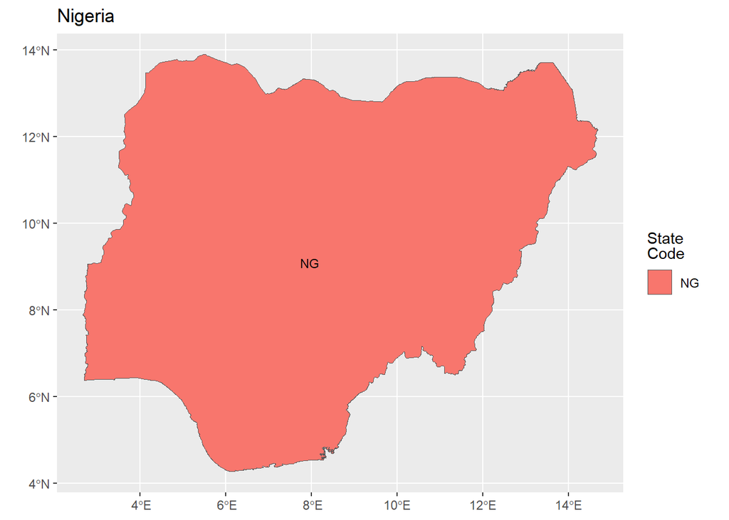

```r
vect_state_geo <- vect("D:/DatosProyecto/SpatialData/Africa/Pais/Nigeria/NGA Admin 2019-2025 OSGOF-Ehealth-UNCS/nga_admin1_topo.topojson")

vect_ng_geo <- vect_state_geo |> aggregate(by = "adm0_pcode")

crs(vect_ng_geo) <- "epsg:4326"

vect_ng_geo$adm0_pcode <- as.factor(vect_ng_geo$adm0_pcode)

# levels(vect_state_geo$adm1_pcode) # Check levels

ggplot(vect_ng_geo)+
  geom_spatvector(aes(fill = adm0_pcode)) +
  geom_spatvector_text(aes(label = adm0_pcode), size = 3) +
  labs(
    title = "Nigeria",
    fill = "State<br>Code") +
  theme(
    plot.title = element_markdown(),
    legend.title = element_markdown(),
    axis.title = element_blank()
  )
```

# Load the Livelihood Zones

The livelihood zones are loaded from disk (see Figure 1).

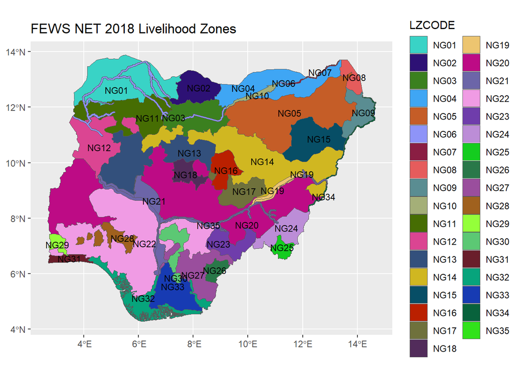

Figure 1: FEWS NET 2018 Livelihood Zones

```r
vect_lz_geo <- vect("D:/DatosProyecto/SpatialData/Africa/Pais/Nigeria/FEWS NET LZ/NG_LHZ_2018/NG_LHZ_2018.topojson")
vect_lz_geo$LZCODE <- as.factor(vect_lz_geo$LZCODE)

crs(vect_lz_geo) <- "epsg:4326"

col.par <- function(n) sample(seq(0.3, 1, length.out = 50), n)
cols <- rainbow(35, s = col.par(35), v = col.par(35))[sample(1:35, 35)]

ggplot(vect_lz_geo) +
  geom_spatvector(aes(fill = LZCODE)) +
  scale_fill_manual(values = cols) +
  geom_spatvector_text(aes(label = LZCODE), size = 3) +
  labs(title = "FEWS NET 2018 Livelihood Zones") +
  theme(
    plot.title = element_markdown(),
    axis.title = element_blank()
  )

rast_lz_geo <- rast(vect_lz_geo, ncols=144, nrows=116)
```

```r
df_lz_sow <- read.csv("D:/DatosProyecto/SpatialData/Africa/Pais/Nigeria/FEWS NET LZ/LZ_Sow_Date.csv")

vect_lz_geo_sowdate  <- merge(vect_lz_geo, df_lz_sow, by = "LZCODE")
```

# Analyse the sowing dates

## Cassava (CCD)

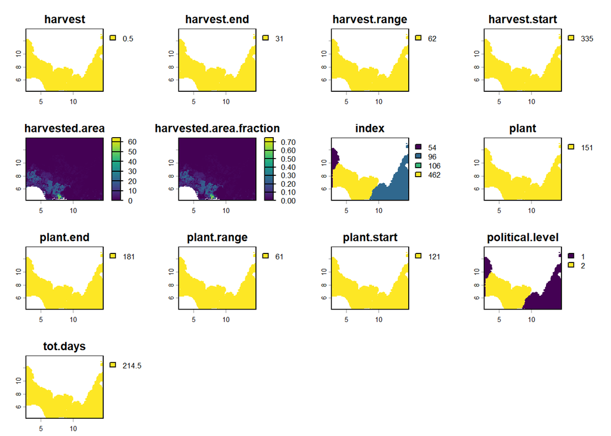

```r
rast_cassava_ccd <- rast("D:/DatosProyecto/SpatialData/Global/Biofisico/SAGE/crop_calendar/Cassava.crop.calendar.nc") |> crop(vect_ng_geo)

crs(rast_cassava_ccd) <- "epsg:4326"

plot(rast_cassava_ccd)
```

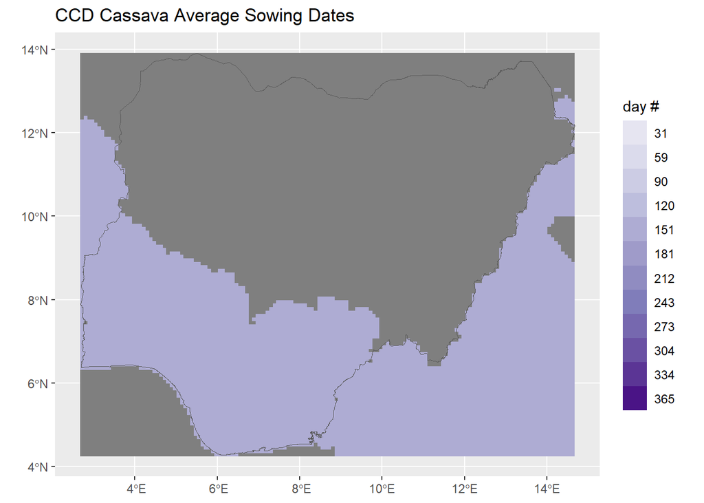

```r
ggplot() +
  geom_spatraster(data = rast_cassava_ccd, aes(fill = plant)) +
    scale_fill_distiller(
    type = "seq",
    palette = "Purples",
    direction = 1,
    limits = c(1, 365),
    breaks = c(31,59,90,120,151,181,212,243,273,304,334,365),
    labels = label_comma(),
    guide = "legend"
  ) +
  geom_spatvector(data = vect_ng_geo, fill = NA) +
  labs(title = "CCD Cassava Average Sowing Dates", fill = "day #") +
  theme(
    plot.title = element_markdown(),
    axis.title = element_blank()
  )
```

## Cassava (FEWSNET)

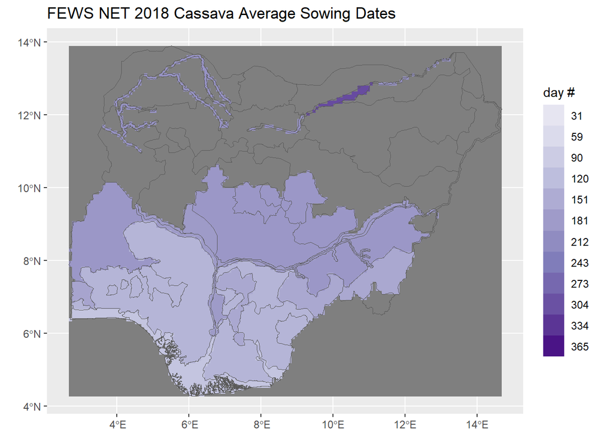

```r
rast_cassava_lz <- rasterize(vect_lz_geo_sowdate, rast_lz_geo, field = "Sow_Date_Avg_Cassava")

ggplot() +
  geom_spatraster(data = rast_cassava_lz) +
    scale_fill_distiller(
    type = "seq",
    palette = "Purples",
    direction = 1,
    limits = c(1, 365),
    breaks = c(31,59,90,120,151,181,212,243,273,304,334,365),
    labels = label_comma(),
    guide = "legend"
  ) +
  geom_spatvector(data = vect_lz_geo, fill = NA) +
  labs(title = "FEWS NET 2018 Cassava Average Sowing Dates", fill = "day #") +
  theme(
    plot.title = element_markdown(),
    axis.title = element_blank()
  )
```

Neither the CCD nor the FEWSNET sources provide cassava sowing dates for all of the country. The CCD gives a single sowing date, and only for the south of Nigeria. FEWSNET provides sowing dates for cassava, but only for livelihood zones in the south and centre of the country.

While, these are the main cassava growing zones we would like to model the suitability for the whole country.

To cover the northern states we can either use the sowing dates for another crop that is grown in the north and which has similar sowing dates to cassava, or use the SACRA dominant crop sowing date (see below).

```r
df_cassava_ccd <- terra::zonal(rast_cassava_ccd$plant, vect_state_geo, fun="mean", na.rm = T)
df_cassava_lz <- terra::zonal(rast_cassava_lz, vect_state_geo, fun="mean", na.rm = T)

df_cassava_sow <- bind_cols(select(as_data_frame(vect_state_geo), adm1_ref_name), df_cassava_ccd, df_cassava_lz )

df_cassava_sow  |>
  DT::datatable(
    rownames = F,
    colnames = c("CCD", "FEWSNET"),
    filter = "bottom",
    selection = list(mode = "none"),
    editable = FALSE,
    options = list(
       order = list(list(1, 'desc'), list(2, 'desc')),
      digits = 0,
      scrollX = TRUE,
      scrollCollapse = TRUE,
      autoWidth = TRUE,
      fixedColumns = list(leftColumns = 2),
      lengthMenu = c(15, 40),
      pageLength = 15
    ))
```

|  | CCD | FEWSNET |
| --- | --- | --- |
| Abia | 151 | 137.8333333333333 |
| Adamawa | 151 | 177.4117647058823 |
| Akwa Ibom | 151 | 128.375 |
| Anambra | 151 | 146.3611111111111 |
| Bauchi |  | 197.1333333333333 |
| Bayelsa | 151 | 105.5 |
| Benue | 151 | 159.5598404255319 |
| Borno | 151 | 197 |
| Cross River | 151 | 133.5392561983471 |
| Delta | 151 | 127.2168367346939 |

[output cut: 27 more lines]

The FEWSNET source gives a better representation of the changes in sowing date. Where FEWSNET data are not available then we will use CCD. Where CCD is not available we will use the Dominant crop 1 from SACRA. For any remaining areas without a sowing date in Nigeria we will use a different crop from CCD or FEWSNET for which data are available.

## Cowpea (CCD)

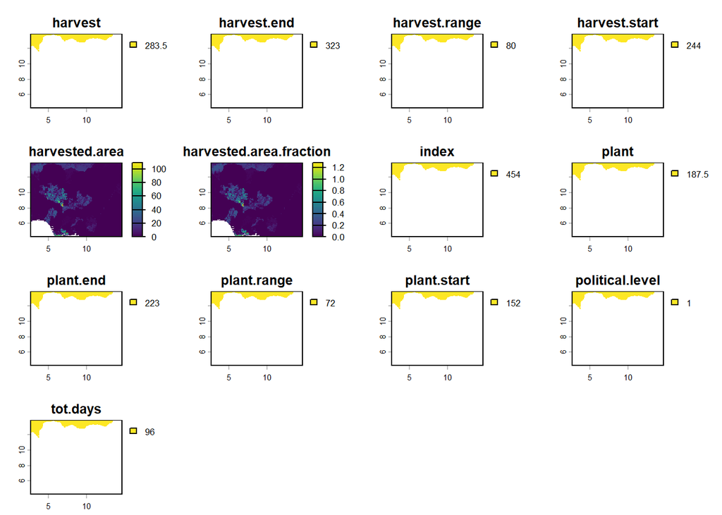

```r
rast_cowpea_ccd <- rast("D:/DatosProyecto/SpatialData/Global/Biofisico/SAGE/crop_calendar/Pulses.crop.calendar.nc") |> crop(vect_ng_geo)

plot(rast_cowpea_ccd)
```

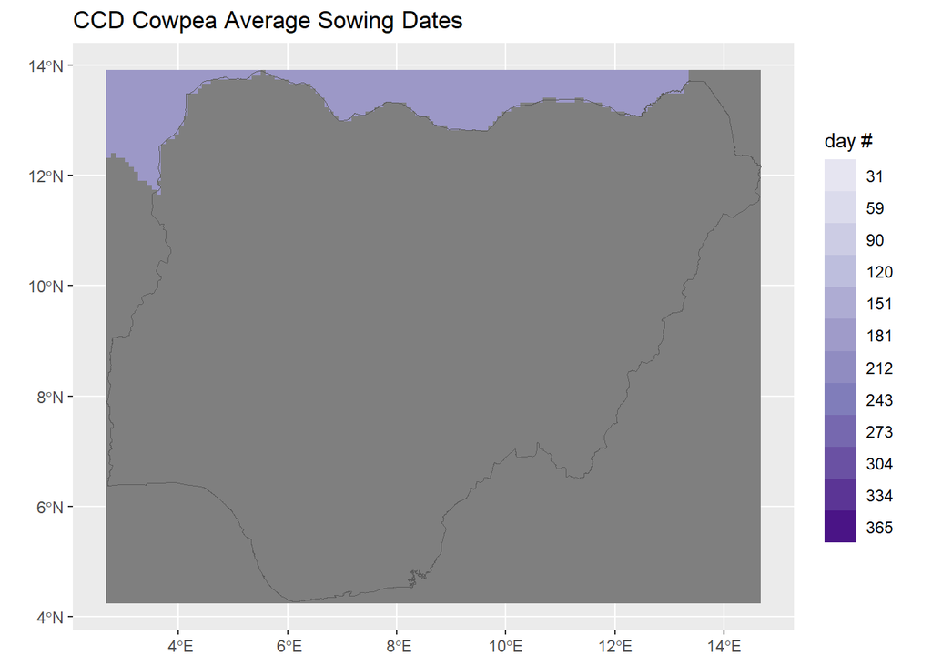

```r
ggplot() +
  geom_spatraster(data = rast_cowpea_ccd, aes(fill = plant)) +
    scale_fill_distiller(
    type = "seq",
    palette = "Purples",
    direction = 1,
    limits = c(1, 365),
    breaks = c(31,59,90,120,151,181,212,243,273,304,334,365),
    labels = label_comma(),
    guide = "legend"
  ) +
  geom_spatvector(data = vect_ng_geo, fill = NA) +
  labs(title = "CCD Cowpea Average Sowing Dates", fill = "day #") +
  theme(
    plot.title = element_markdown(),
    axis.title = element_blank()
  )
```

## Cowpea (FEWSNET)

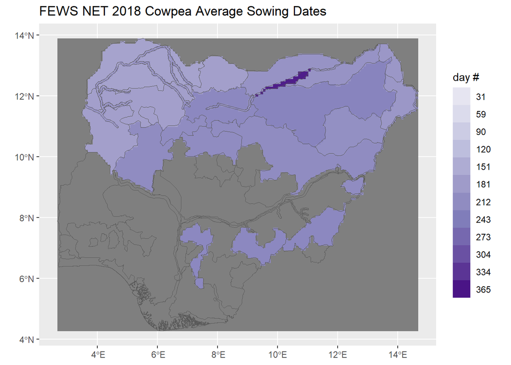

```r
rast_cowpea_lz <- rasterize(vect_lz_geo_sowdate, rast_lz_geo, field = "Sow_Date_Avg_Cowpea")

ggplot() +
  geom_spatraster(data = rast_cowpea_lz)+
    scale_fill_distiller(
    type = "seq",
    palette = "Purples",
    direction = 1,
    limits = c(1, 365),
    breaks = c(31,59,90,120,151,181,212,243,273,304,334,365),
    labels = label_comma(),
    guide = "legend"
  ) +
  geom_spatvector(data = vect_lz_geo, fill = NA) +
  labs(title = "FEWS NET 2018 Cowpea Average Sowing Dates", fill = "day #") +
  theme(
    plot.title = element_markdown(),
    axis.title = element_blank()
  )
```

The FEWSNET source gives sowing dates for most of the north of Nigeria as well as livelihood zones in the centre of the country.

So for cowpea, the situation is the reverse of for cassava. Once again we will have to seek reasonable estimates of sowing dates for half of the country.

```r
df_cowpea_ccd <- terra::zonal(rast_cowpea_ccd$plant, vect_state_geo, fun="mean", na.rm = T)
df_cowpea_lz <- terra::zonal(rast_cowpea_lz, vect_state_geo, fun="mean", na.rm = T)

df_cowpea_sow <- bind_cols(select(as_data_frame(vect_state_geo), adm1_ref_name), df_cowpea_ccd, df_cowpea_lz )

df_cowpea_sow  |>
  DT::datatable(
    rownames = F,
    colnames = c("CCD", "FEWSNET"),
    filter = "bottom",
    selection = list(mode = "none"),
    editable = FALSE,
    options = list(
      order = list(list(1, 'desc'), list(2, 'desc')),
      digits = 0,
      scrollX = TRUE,
      scrollCollapse = TRUE,
      autoWidth = TRUE,
      fixedColumns = list(leftColumns = 2),
      lengthMenu = c(15, 40),
      pageLength = 15
    ))
```

|  | CCD | FEWSNET |
| --- | --- | --- |
| Abia |  | 219.5 |
| Adamawa |  | 212.1878787878788 |
| Akwa Ibom |  |  |
| Anambra |  | 219.5 |
| Bauchi |  | 218.1226235741445 |
| Bayelsa |  |  |
| Benue |  | 219.5 |
| Borno | 187.5 | 208.7073170731707 |
| Cross River |  | 219.5 |
| Delta |  |  |

[output cut: 27 more lines]

## Maize (CCD)

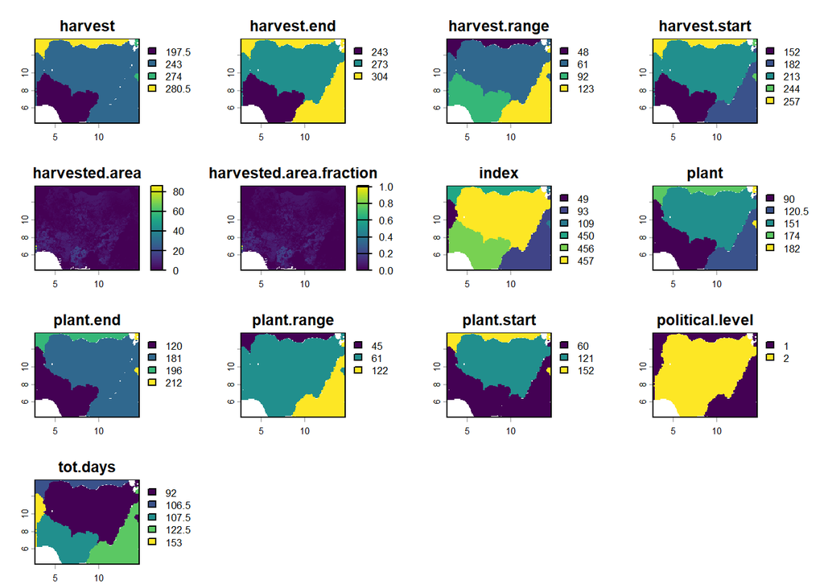

```r
rast_maize_ccd <- rast("D:/DatosProyecto/SpatialData/Global/Biofisico/SAGE/crop_calendar/Maize.crop.calendar.nc") |> crop(vect_ng_geo)

plot(rast_maize_ccd)
```

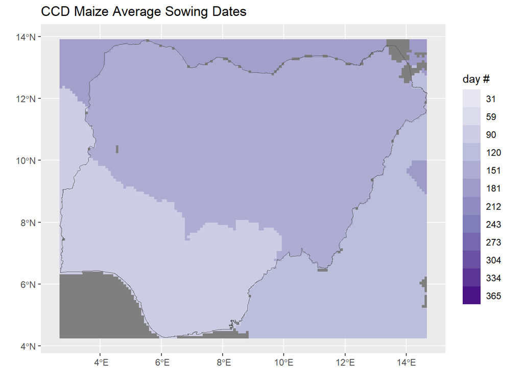

```r
ggplot() +
  geom_spatraster(data = rast_maize_ccd, aes(fill = plant)) +
    scale_fill_distiller(
    type = "seq",
    palette = "Purples",
    direction = 1,
    limits = c(1, 365),
    breaks = c(31,59,90,120,151,181,212,243,273,304,334,365),
    labels = label_comma(),
    guide = "legend"
  ) +
  geom_spatvector(data = vect_ng_geo, fill = NA) +
  labs(title = "CCD Maize Average Sowing Dates", fill = "day #") +
  theme(
    plot.title = element_markdown(),
    axis.title = element_blank()
  )
```

## Maize (FEWSNET)

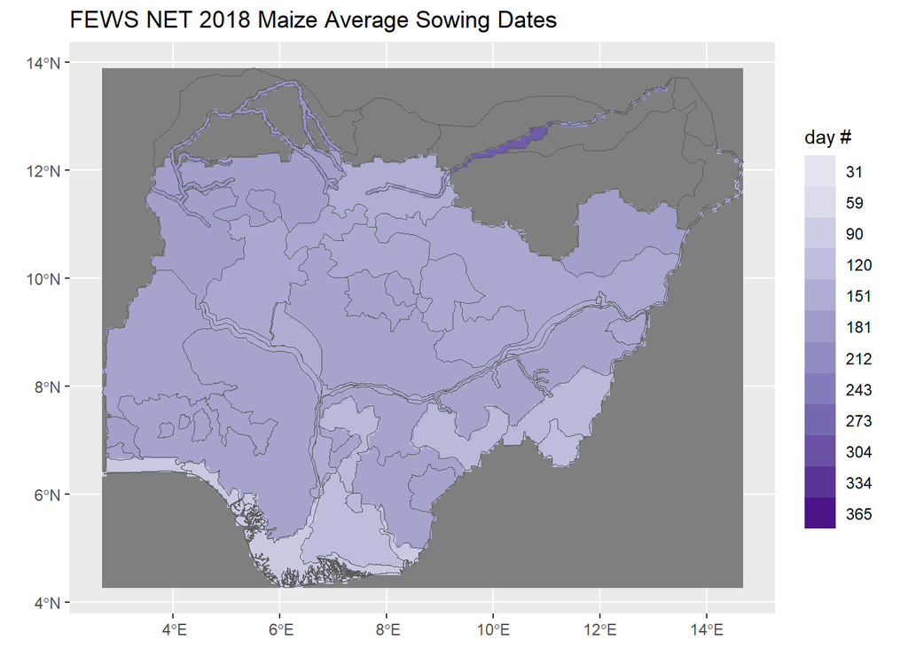

```r
rast_maize_lz <- rasterize(vect_lz_geo_sowdate, rast_lz_geo, field = "Sow_Date_Avg_Maize")

ggplot() +
  geom_spatraster(data = rast_maize_lz)+
    scale_fill_distiller(
    type = "seq",
    palette = "Purples",
    direction = 1,
    limits = c(1, 365),
    breaks = c(31,59,90,120,151,181,212,243,273,304,334,365),
    labels = label_comma(),
    guide = "legend"
  ) +
  geom_spatvector(data = vect_lz_geo, fill = NA) +
  labs(title = "FEWS NET 2018 Maize Average Sowing Dates", fill = "day #") +
  theme(
    plot.title = element_markdown(),
    axis.title = element_blank()
  )
```

The sowing dates for maize are complete in the CCD source, although there are only two dates, one for the south of the country (31st March), and one for the north (31st May). FEWSNET provides sowing dates for almost all of Nigeria, except for the far north of the country.

```r
df_maize_ccd <- terra::zonal(rast_maize_ccd$plant, vect_state_geo, fun="mean", na.rm = T)
df_maize_lz <- terra::zonal(rast_maize_lz, vect_state_geo, fun="mean", na.rm = T)

df_maize_sow <- bind_cols(select(as_data_frame(vect_state_geo), adm1_ref_name), df_maize_ccd, df_maize_lz )

df_maize_sow  |>
  DT::datatable(
    rownames = F,
    colnames = c("CCD", "FEWSNET"),
    filter = "bottom",
    selection = list(mode = "none"),
    editable = FALSE,
    options = list(
      order = list(list(1, 'desc'), list(2, 'desc')),
      digits = 0,
      scrollX = TRUE,
      scrollCollapse = TRUE,
      autoWidth = TRUE,
      fixedColumns = list(leftColumns = 2),
      lengthMenu = c(15, 40),
      pageLength = 15
    ))
```

|  | CCD | FEWSNET |
| --- | --- | --- |
| Abia | 90 | 122.1666666666667 |
| Adamawa | 150.9319196428571 | 155.8658536585366 |
| Akwa Ibom | 90 | 115 |
| Anambra | 90 | 132.5277777777778 |
| Bauchi | 151 | 159.3333333333333 |
| Bayelsa | 90 | 97 |
| Benue | 92.61662198391421 | 152.7992021276596 |
| Borno | 150.9907178217822 | 173.2314049586777 |
| Cross River | 90.25206611570248 | 160.154958677686 |
| Delta | 90 | 142.1887755102041 |

[output cut: 27 more lines]

The CCD sowing dates for Maize are generally earlier than those in the FEWSNET data source, especially in the south.

The FEWSNET source gives a better representation of the changes in sowing date. Where FEWSNET data are not available in the north, then we will use CCD.

## Rice (CCD)

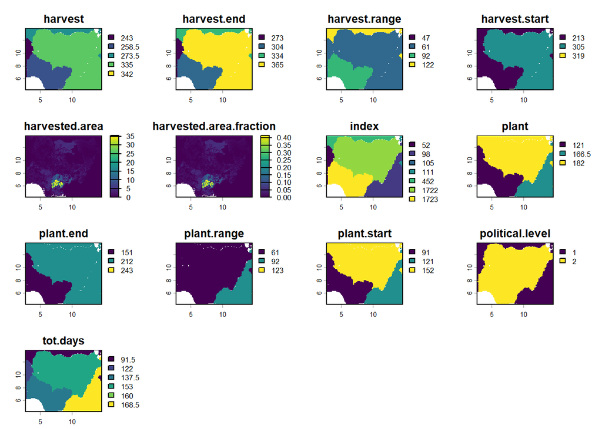

```r
rast_rice_ccd <- rast("D:/DatosProyecto/SpatialData/Global/Biofisico/SAGE/crop_calendar/Rice.crop.calendar.nc") |> crop(vect_ng_geo)

plot(rast_rice_ccd)
```

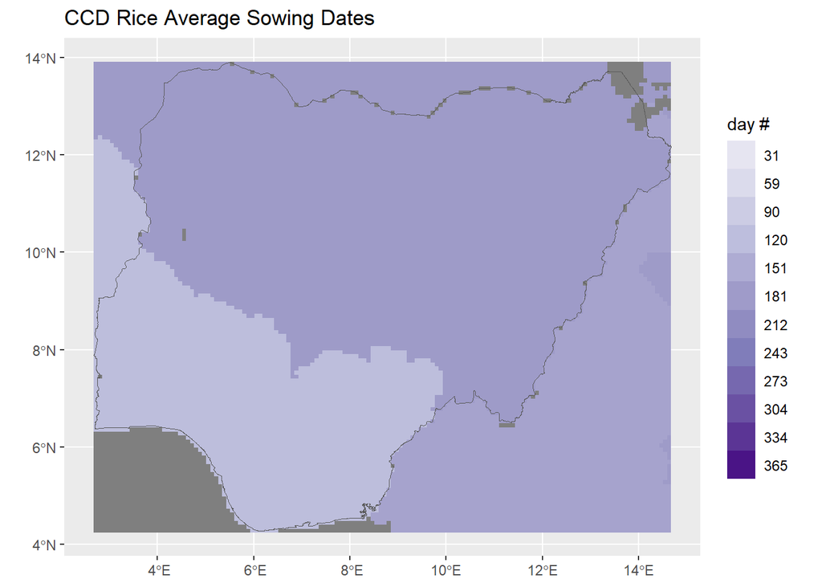

```r
ggplot() +
  geom_spatraster(data = rast_rice_ccd, aes(fill = plant)) +
    scale_fill_distiller(
    type = "seq",
    palette = "Purples",
    direction = 1,
    limits = c(1, 365),
    breaks = c(31,59,90,120,151,181,212,243,273,304,334,365),
    labels = label_comma(),
    guide = "legend"
  ) +
  geom_spatvector(data = vect_ng_geo, fill = NA) +
  labs(title = "CCD Rice Average Sowing Dates", fill = "day #") +
  theme(
    plot.title = element_markdown(),
    axis.title = element_blank()
  )
```

## Rice (FEWSNET)

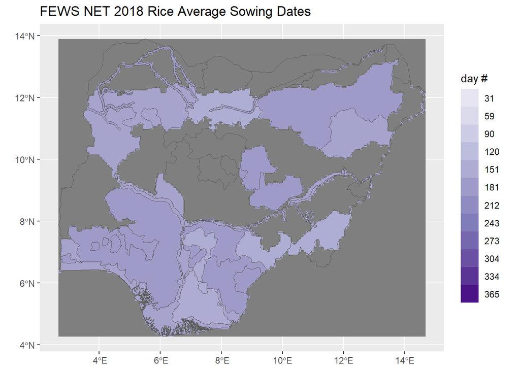

```r
rast_rice_lz <- rasterize(vect_lz_geo_sowdate, rast_lz_geo, field = "Sow_Date_Avg_Rice")

ggplot() +
  geom_spatraster(data = rast_rice_lz)+
    scale_fill_distiller(
    type = "seq",
    palette = "Purples",
    direction = 1,
    limits = c(1, 365),
    breaks = c(31,59,90,120,151,181,212,243,273,304,334,365),
    labels = label_comma(),
    guide = "legend"
  ) +
  geom_spatvector(data = vect_lz_geo, fill = NA) +
  labs(title = "FEWS NET 2018 Rice Average Sowing Dates", fill = "day #") +
  theme(
    plot.title = element_markdown(),
    axis.title = element_blank()
  )
```

The rainfed rice sowing dates in the FEWSNET source are sparser than for maize, especially in the centre of the country and in the far north. There are sowing dates for irrigated rice in more livelihood zones, but we will not be modelling the suitability of irrigated crops.

```r
df_rice_ccd <- terra::zonal(rast_rice_ccd$plant, vect_state_geo, fun="mean", na.rm = T)
df_rice_lz <- terra::zonal(rast_rice_lz, vect_state_geo, fun="mean", na.rm = T)

df_rice_sow <- bind_cols(select(as_data_frame(vect_state_geo), adm1_ref_name), df_rice_ccd, df_rice_lz )

df_rice_sow  |>
  DT::datatable(
    rownames = F,
    colnames = c("CCD", "FEWSNET"),
    filter = "bottom",
    selection = list(mode = "none"),
    editable = FALSE,
    options = list(
      order = list(list(1, 'desc'), list(2, 'desc')),
      digits = 0,
      scrollX = TRUE,
      scrollCollapse = TRUE,
      autoWidth = TRUE,
      fixedColumns = list(leftColumns = 2),
      lengthMenu = c(15, 40),
      pageLength = 15
    ))
```

|  | CCD | FEWSNET |
| --- | --- | --- |
| Abia | 121 | 151.7456140350877 |
| Adamawa | 181.9654017857143 | 157.3358778625954 |
| Akwa Ibom | 121 | 154.875 |
| Anambra | 121 | 158.6296296296296 |
| Bauchi | 182 | 181 |
| Bayelsa | 121 | 166.5 |
| Benue | 123.6166219839142 | 166.1316725978648 |
| Borno | 181.9808168316832 | 174.8285968028419 |
| Cross River | 121.3760330578512 | 179.4896694214876 |
| Delta | 121 | 175.5255102040816 |

[output cut: 27 more lines]

For many of the northern states the sowing dates are well matched. However, the CCD source displays a large change in sowing dates for the southern states. In contrast the FEWSNET source has a gentler gradient from early to late as one moves northward.

The FEWSNET source gives a better representation of the changes in sowing date. Where FEWSNET data are not available in the north, then we will use CCD.

## Sweet Potato (CCD)

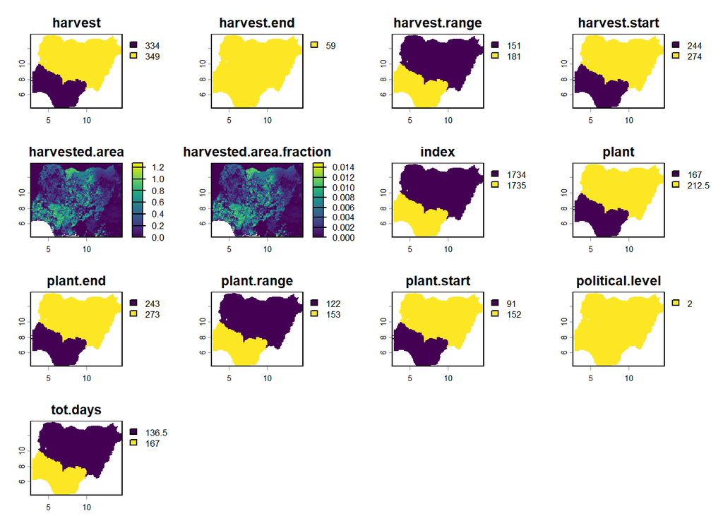

```r
rast_spot_ccd <- rast("D:/DatosProyecto/SpatialData/Global/Biofisico/SAGE/crop_calendar/Sweet.Potatoes.crop.calendar.nc") |> crop(vect_ng_geo)

plot(rast_spot_ccd)
```

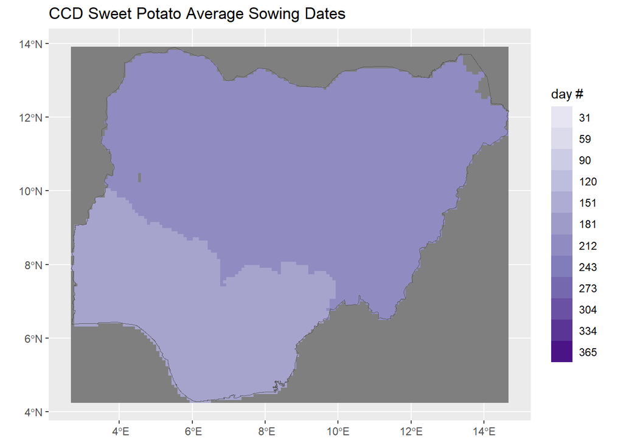

```r
ggplot() +
  geom_spatraster(data = rast_spot_ccd, aes(fill = plant)) +
    scale_fill_distiller(
    type = "seq",
    palette = "Purples",
    direction = 1,
    limits = c(1, 365),
    breaks = c(31,59,90,120,151,181,212,243,273,304,334,365),
    labels = label_comma(),
    guide = "legend"
  ) +
  geom_spatvector(data = vect_ng_geo, fill = NA) +
  labs(title = "CCD Sweet Potato Average Sowing Dates", fill = "day #") +
  theme(
    plot.title = element_markdown(),
    axis.title = element_blank()
  )
```

## Sweet Potato (FEWSNET)

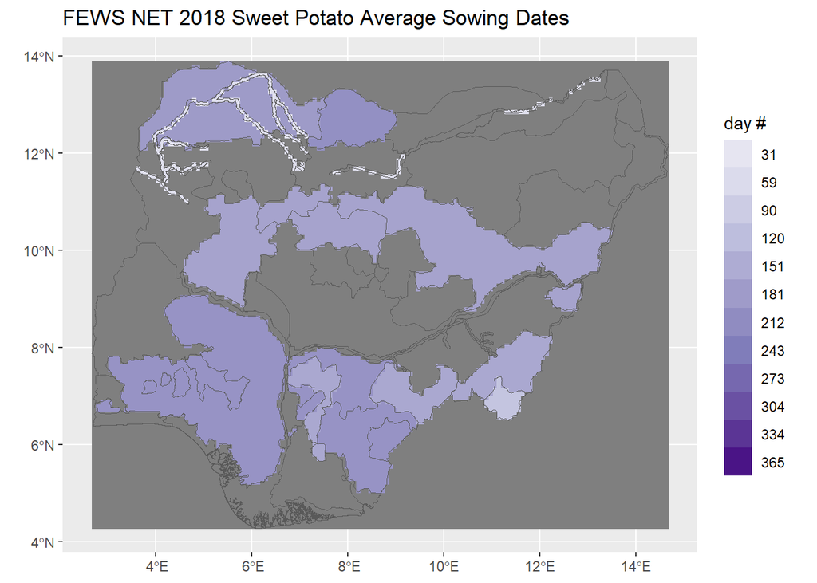

```r
rast_spot_lz <- rasterize(vect_lz_geo_sowdate, rast_lz_geo, field = "Sow_Date_Avg_Spot")

ggplot() +
  geom_spatraster(data = rast_spot_lz)+
    scale_fill_distiller(
    type = "seq",
    palette = "Purples",
    direction = 1,
    limits = c(1, 365),
    breaks = c(31,59,90,120,151,181,212,243,273,304,334,365),
    labels = label_comma(),
    guide = "legend"
  ) +
  geom_spatvector(data = vect_lz_geo, fill = NA) +
  labs(title = "FEWS NET 2018 Sweet Potato Average Sowing Dates", fill = "day #") +
  theme(
    plot.title = element_markdown(),
    axis.title = element_blank()
  )
```

Sweet Potato sowing dates in the CCD source are later in the year than for other crops. Likewise in the FEWSNET source, although this source has missing data from many livelihood zones.

```r
df_spot_ccd <- terra::zonal(rast_spot_ccd$plant, vect_state_geo, fun="mean", na.rm = T)
df_spot_lz <- terra::zonal(rast_spot_lz, vect_state_geo, fun="mean", na.rm = T)

df_spot_sow <- bind_cols(select(as_data_frame(vect_state_geo), adm1_ref_name), df_spot_ccd, df_spot_lz )

df_spot_sow  |>
  DT::datatable(
    rownames = F,
    colnames = c("CCD", "FEWSNET"),
    filter = "bottom",
    selection = list(mode = "none"),
    editable = FALSE,
    options = list(
      order = list(list(1, 'desc'), list(2, 'desc')),
      digits = 0,
      scrollX = TRUE,
      scrollCollapse = TRUE,
      autoWidth = TRUE,
      fixedColumns = list(leftColumns = 2),
      lengthMenu = c(15, 40),
      pageLength = 15
    ))
```

|  | CCD | FEWSNET |
| --- | --- | --- |
| Abia | 167 | 164.4285714285714 |
| Adamawa | 212.5 | 164.7752613240418 |
| Akwa Ibom | 167 |  |
| Anambra | 167 | 191.5714285714286 |
| Bauchi | 212.5 | 166.5 |
| Bayelsa | 167 |  |
| Benue | 168.9517426273459 | 178.4384615384615 |
| Borno | 212.5 | 85.83333333333333 |
| Cross River | 167 | 196.6561085972851 |
| Delta | 167 | 197 |

[output cut: 27 more lines]

The FEWSNET source gives a better representation of the changes in sowing date. Where FEWSNET data are not available in the north, then we will use CCD.

## Dominant Crop 1 (SACRA)

The SACRA dataset is organised differently than the other two sources and is based on vegetation indices using remotely sensed imagery.

The source provides a date for when the landscape starts to green in response to the start of the rainy season. The dominant crop in each raster cell is also provided, this is based on the harvested area from agricultural censuses or surveys.

The SACRA source provides sowing dates for up to three growing seasons in a calendar year.

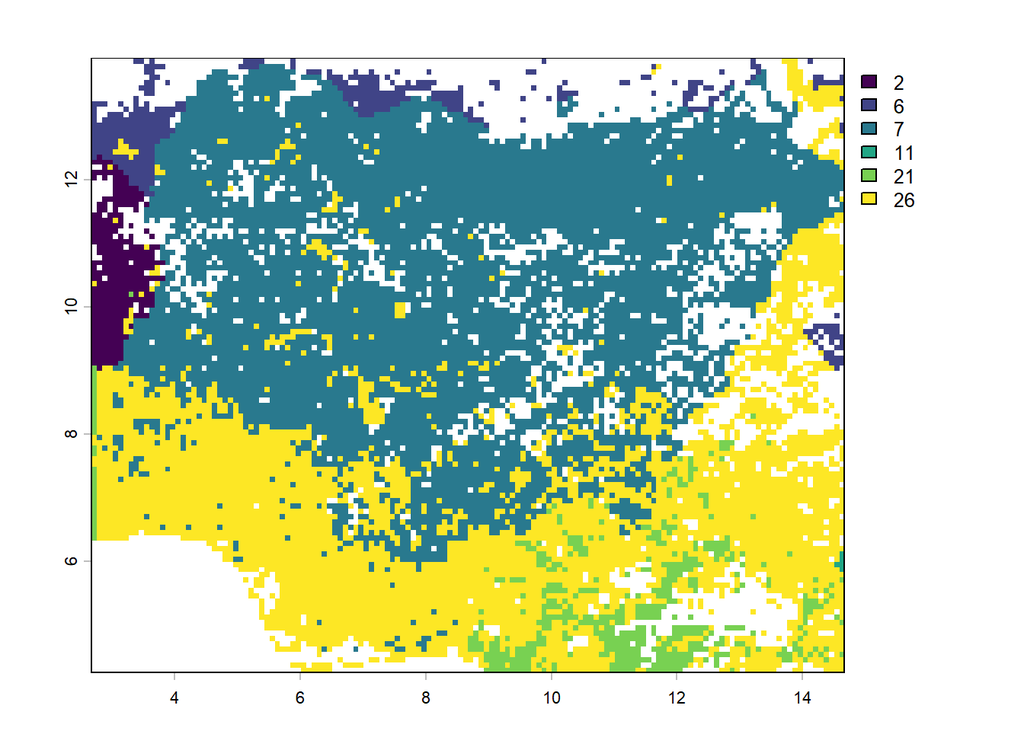

```r
rast_domcrop1_sacra <- rast("D:/DatosProyecto/SpatialData/Global/Biofisico/SACRA Crop Calendar/CALEND/CRPMAP_5min_all_1st_CRP_AF.asc") |> crop(vect_ng_geo)

plot(rast_domcrop1_sacra)
```

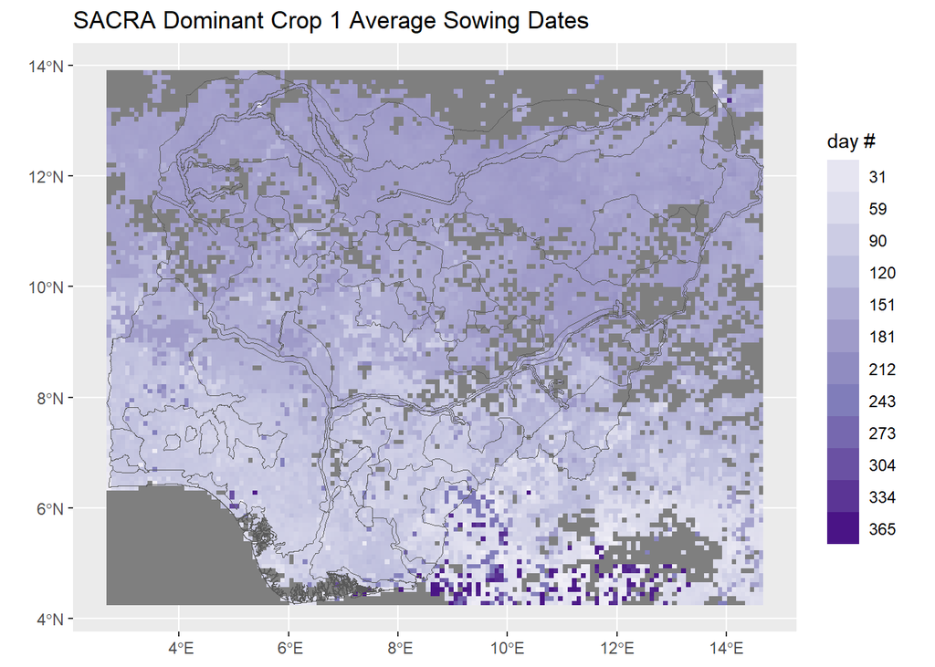

```r
rast_sow1_sacra <- rast("D:/DatosProyecto/SpatialData/Global/Biofisico/SACRA Crop Calendar/CALEND/CRPMAP_5min_all_1st_SOW_AF.asc") |> crop(vect_ng_geo)

ggplot() +
  geom_spatraster(data = rast_sow1_sacra)+
    scale_fill_distiller(
    type = "seq",
    palette = "Purples",
    direction = 1,
    limits = c(1, 365),
    breaks = c(31,59,90,120,151,181,212,243,273,304,334,365),
    labels = label_comma(),
    guide = "legend"
  ) +
  geom_spatvector(data = vect_lz_geo, fill = NA) +
  labs(title = "SACRA Dominant Crop 1 Average Sowing Dates", fill = "day #") +
  theme(
    plot.title = element_markdown(),
    axis.title = element_blank()
  )
```

2 = Maize, 6 = Millet, 7 = Sorghum, 11 = Cassava, 21 = Cotton, 26 = Others annual

The progression of the sowing date from south to north is noticeably smoother than the CCD source.

## Dominant Crop 2 (SACRA)

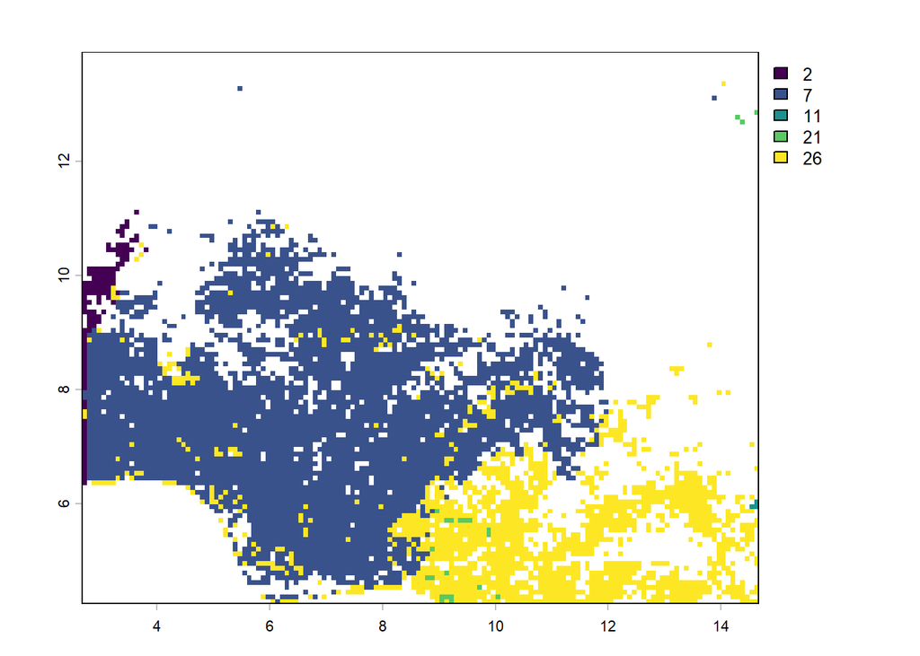

```r
rast_domcrop2_sacra <- rast("D:/DatosProyecto/SpatialData/Global/Biofisico/SACRA Crop Calendar/CALEND/CRPMAP_5min_all_2nd_CRP_AF.asc") |> crop(vect_ng_geo)

plot(rast_domcrop2_sacra)
```

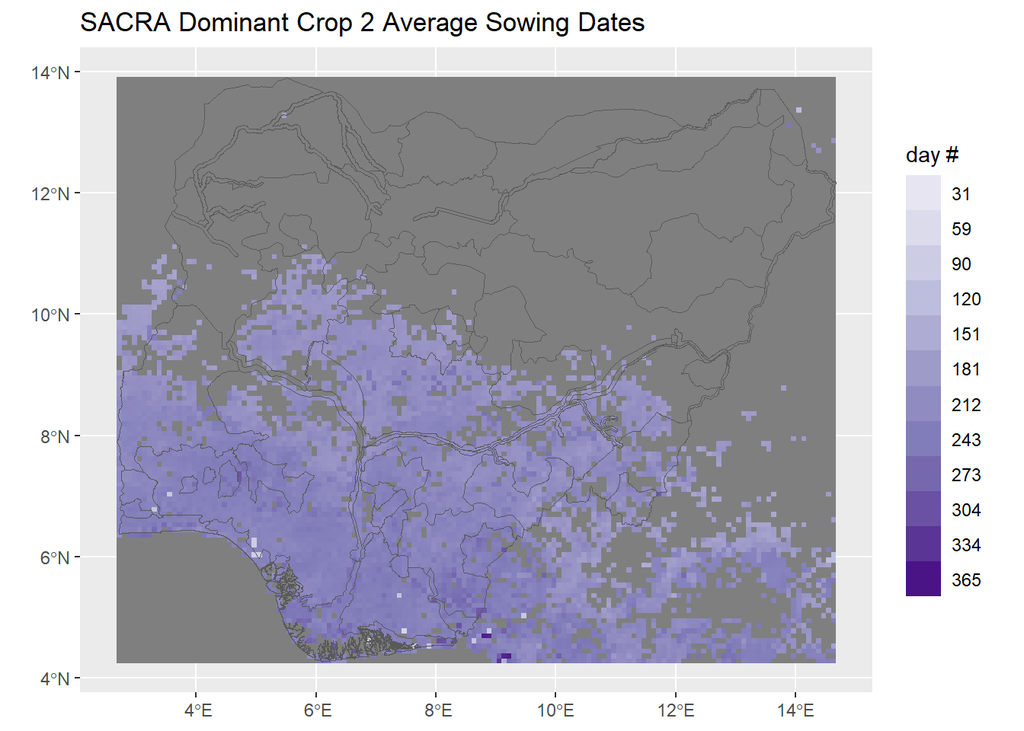

```r
rast_sow2_sacra <- rast("D:/DatosProyecto/SpatialData/Global/Biofisico/SACRA Crop Calendar/CALEND/CRPMAP_5min_all_2nd_SOW_AF.asc") |> crop(vect_ng_geo)

ggplot() +
  geom_spatraster(data = rast_sow2_sacra)+
    scale_fill_distiller(
    type = "seq",
    palette = "Purples",
    direction = 1,
    limits = c(1, 365),
    breaks = c(31,59,90,120,151,181,212,243,273,304,334,365),
    labels = label_comma(),
    guide = "legend"
  ) +
  geom_spatvector(data = vect_lz_geo, fill = NA) +
  labs(title = "SACRA Dominant Crop 2 Average Sowing Dates", fill = "day #") +
  theme(
    plot.title = element_markdown(),
    axis.title = element_blank()
  )
```

## Dominant Crop 3 (SACRA)

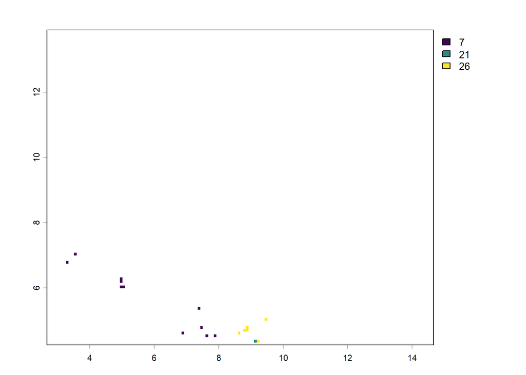

```r
rast_domcrop3_sacra <- rast("D:/DatosProyecto/SpatialData/Global/Biofisico/SACRA Crop Calendar/CALEND/CRPMAP_5min_all_3rd_CRP_AF.asc") |> crop(vect_ng_geo)

plot(rast_domcrop3_sacra)
```

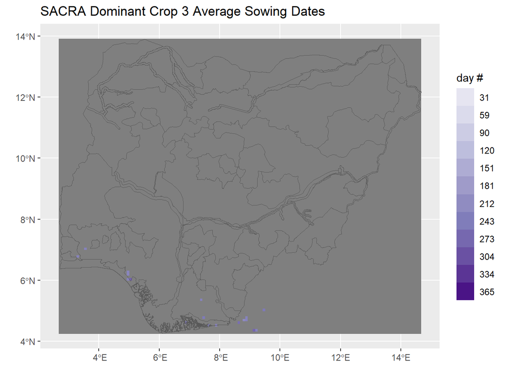

```r
rast_sow3_sacra <- rast("D:/DatosProyecto/SpatialData/Global/Biofisico/SACRA Crop Calendar/CALEND/CRPMAP_5min_all_3rd_SOW_AF.asc") |> crop(vect_ng_geo)

ggplot() +
  geom_spatraster(data = rast_sow3_sacra)+
    scale_fill_distiller(
    type = "seq",
    palette = "Purples",
    direction = 1,
    limits = c(1, 365),
    breaks = c(31,59,90,120,151,181,212,243,273,304,334,365),
    labels = label_comma(),
    guide = "legend"
  ) +
  geom_spatvector(data = vect_lz_geo, fill = NA) +
  labs(title = "SACRA Dominant Crop 3 Average Sowing Dates", fill = "day #") +
  theme(
    plot.title = element_markdown(),
    axis.title = element_blank()
  )
```

# Construct sowing dates for each crop

## Cassava

FEWSNET > CCD > SACRA > different crop from CCD for which data are available (sweet potato)

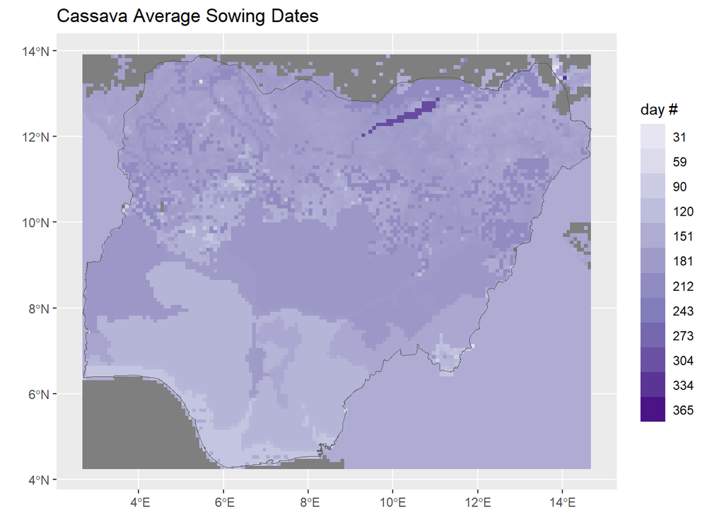

```r
rast_cassava_lz_rsmp <- resample(rast_cassava_lz, rast_cassava_ccd )
rast_cassava_sacra <- resample(rast_sow1_sacra, rast_cassava_ccd )

rast_cassava <- ifel(
  !is.na(rast_cassava_lz_rsmp),
  rast_cassava_lz_rsmp,
  ifel(
    !is.na(rast_cassava_ccd$plant),
    rast_cassava_ccd$plant,
    ifel(!is.na(rast_cassava_sacra), rast_cassava_sacra, rast_spot_ccd$plant)
  )
)


ggplot() +
  geom_spatraster(data = rast_cassava) +
    scale_fill_distiller(
    type = "seq",
    palette = "Purples",
    direction = 1,
    limits = c(1, 365),
    breaks = c(31,59,90,120,151,181,212,243,273,304,334,365),
    labels = label_comma(),
    guide = "legend"
  ) +
  geom_spatvector(data = vect_ng_geo, fill = NA) +
  labs(title = "Cassava Average Sowing Dates", fill = "day #") +
  theme(
    plot.title = element_markdown(),
    axis.title = element_blank()
  )
```

```r
writeRaster(rast_cassava, "E:/repos/IRM_shiny/data/spatial_data/onset_cassava_generic_nigeria.tif", overwrite=TRUE)
```

## Cowpea

FEWSNET > SACRA > different crop from CCD for which data are available (maize)

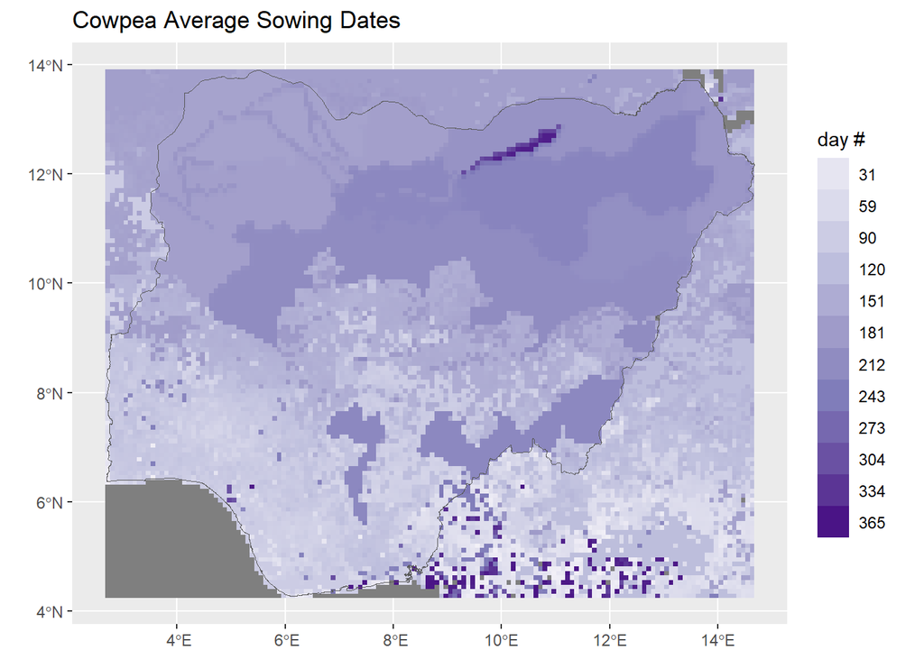

```r
rast_cowpea_lz_rsmp <- resample(rast_cowpea_lz, rast_cowpea_ccd )
rast_cowpea_sacra <- resample(rast_sow1_sacra, rast_cowpea_ccd )

rast_cowpea <- ifel(
  !is.na(rast_cowpea_lz_rsmp),
  rast_cowpea_lz_rsmp,
    ifel(!is.na(rast_cowpea_sacra), rast_cowpea_sacra, rast_maize_ccd$plant)
  )


ggplot() +
  geom_spatraster(data = rast_cowpea) +
    scale_fill_distiller(
    type = "seq",
    palette = "Purples",
    direction = 1,
    limits = c(1, 365),
    breaks = c(31,59,90,120,151,181,212,243,273,304,334,365),
    labels = label_comma(),
    guide = "legend"
  ) +
  geom_spatvector(data = vect_ng_geo, fill = NA) +
  labs(title = "Cowpea Average Sowing Dates", fill = "day #") +
  theme(
    plot.title = element_markdown(),
    axis.title = element_blank()
  )
```

```r
writeRaster(rast_cowpea, "E:/repos/IRM_shiny/data/spatial_data/onset_cowpea_generic_nigeria.tif", overwrite=TRUE)
```

## Maize

FEWSNET > CCD

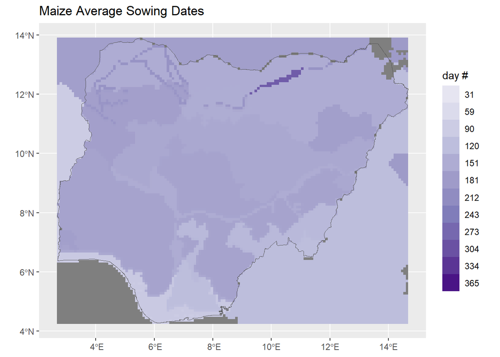

```r
rast_maize_lz_rsmp <- resample(rast_maize_lz, rast_maize_ccd )
rast_maize_sacra <- resample(rast_sow1_sacra, rast_maize_ccd )

rast_maize <- ifel(
  !is.na(rast_maize_lz_rsmp),  rast_maize_lz_rsmp, rast_maize_ccd$plant)


ggplot() +
  geom_spatraster(data = rast_maize) +
    scale_fill_distiller(
    type = "seq",
    palette = "Purples",
    direction = 1,
    limits = c(1, 365),
    breaks = c(31,59,90,120,151,181,212,243,273,304,334,365),
    labels = label_comma(),
    guide = "legend"
  ) +
  geom_spatvector(data = vect_ng_geo, fill = NA) +
  labs(title = "Maize Average Sowing Dates", fill = "day #") +
  theme(
    plot.title = element_markdown(),
    axis.title = element_blank()
  )
```

```r
writeRaster(rast_maize, "E:/repos/IRM_shiny/data/spatial_data/onset_maize_generic_nigeria.tif", overwrite=TRUE)
```

## Rice

FEWSNET > CCD

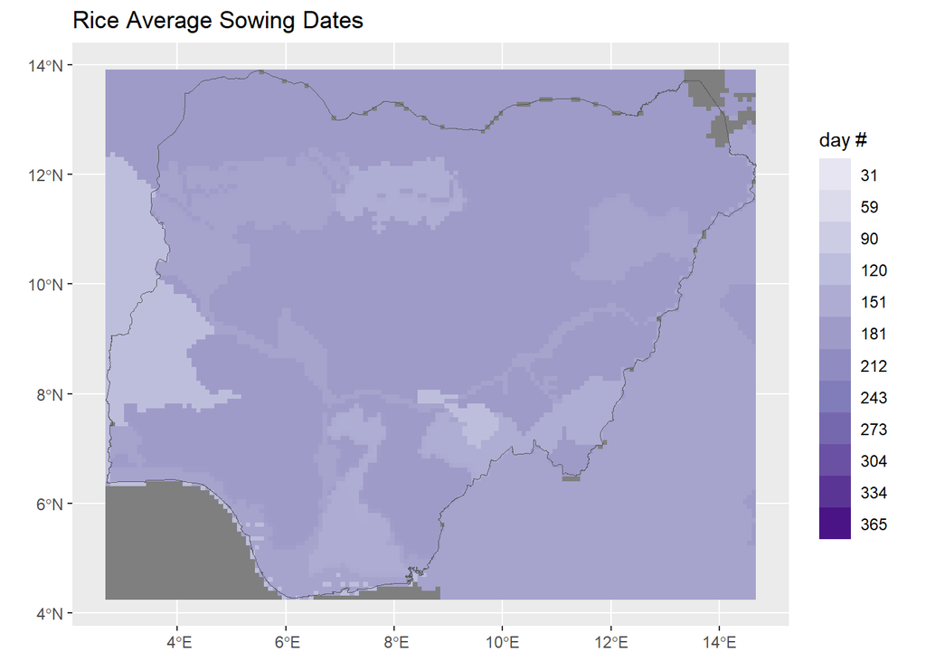

```r
rast_rice_lz_rsmp <- resample(rast_rice_lz, rast_rice_ccd )
rast_rice_sacra <- resample(rast_sow1_sacra, rast_rice_ccd )

rast_rice <- ifel(
  !is.na(rast_rice_lz_rsmp),  rast_rice_lz_rsmp, rast_rice_ccd$plant)


ggplot() +
  geom_spatraster(data = rast_rice) +
    scale_fill_distiller(
    type = "seq",
    palette = "Purples",
    direction = 1,
    limits = c(1, 365),
    breaks = c(31,59,90,120,151,181,212,243,273,304,334,365),
    labels = label_comma(),
    guide = "legend"
  ) +
  geom_spatvector(data = vect_ng_geo, fill = NA) +
  labs(title = "Rice Average Sowing Dates", fill = "day #") +
  theme(
    plot.title = element_markdown(),
    axis.title = element_blank()
  )
```

```r
writeRaster(rast_rice, "E:/repos/IRM_shiny/data/spatial_data/onset_rice_generic_nigeria.tif", overwrite=TRUE)
```

## Sweet Potato

FEWSNET > CCD

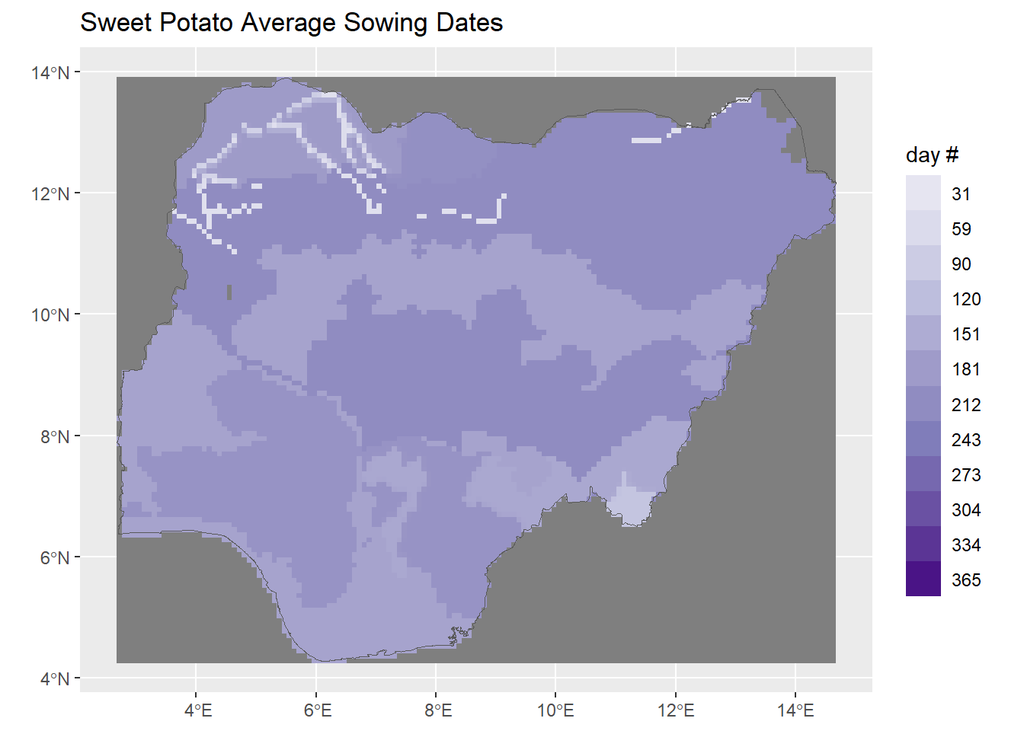

```r
rast_spot_lz_rsmp <- resample(rast_spot_lz, rast_spot_ccd )
rast_spot_sacra <- resample(rast_sow1_sacra, rast_spot_ccd )

rast_spot <- ifel(
  !is.na(rast_spot_lz_rsmp),  rast_spot_lz_rsmp, rast_spot_ccd$plant)


ggplot() +
  geom_spatraster(data = rast_spot) +
    scale_fill_distiller(
    type = "seq",
    palette = "Purples",
    direction = 1,
    limits = c(1, 365),
    breaks = c(31,59,90,120,151,181,212,243,273,304,334,365),
    labels = label_comma(),
    guide = "legend"
  ) +
  geom_spatvector(data = vect_ng_geo, fill = NA) +
  labs(title = "Sweet Potato Average Sowing Dates", fill = "day #") +
  theme(
    plot.title = element_markdown(),
    axis.title = element_blank()
  )
```

```r
writeRaster(rast_spot, "E:/repos/IRM_shiny/data/spatial_data/onset_spot_generic_nigeria.tif", overwrite=TRUE)
```